# PS4

Lan Shi 60625430

12/11/2018

## Question 1

All-time Leader in Hits for Each Birth Country

| Player | Country of Birth | Debut | Hits |
| --- | --- | --- | --- |
| Ichiro Suzuki | Japan | 2001-04-02 | 262 |
| George Sisler | USA | 1915-06-28 | 257 |
| Rod Carew | Panama | 1967-04-11 | 239 |
| Matty Alou | D.R. | 1960-09-26 | 231 |
| Tip O’Neill | CAN | 1883-05-05 | 225 |
| Jose Altuve | Venezuela | 2011-07-20 | 225 |
| Tony Oliva | Cuba | 1962-09-09 | 217 |
| Roberto Clemente | P.R. | 1955-04-17 | 211 |
| Vinny Castilla | Mexico | 1991-09-01 | 206 |

## Question 2

#### a)

Results for q2 (a)

| rho | sigma | metric | method | est | se |
| --- | --- | --- | --- | --- | --- |
| -0.75 | 1 | fwer | holm | 0.0464000 | 0.0021035 |
| -0.75 | 1 | fwer | bonferroni | 0.0453000 | 0.0020796 |
| -0.75 | 1 | fwer | BH | 0.2535000 | 0.0043501 |
| -0.75 | 1 | fwer | BY | 0.0363000 | 0.0018704 |
| -0.75 | 1 | fdr | holm | 0.0121950 | 0.0006089 |
| -0.75 | 1 | fdr | bonferroni | 0.0120279 | 0.0006076 |
| -0.75 | 1 | fdr | BH | 0.0460991 | 0.0008756 |
| -0.75 | 1 | fdr | BY | 0.0085378 | 0.0004963 |
| -0.75 | 1 | sens | holm | 0.3256700 | 0.0015607 |
| -0.75 | 1 | sens | bonferroni | 0.3226900 | 0.0015413 |
| -0.75 | 1 | sens | BH | 0.5164400 | 0.0020634 |
| -0.75 | 1 | sens | BY | 0.2860200 | 0.0018901 |
| -0.75 | 1 | spec | holm | 0.9994656 | 0.0000246 |
| -0.75 | 1 | spec | bonferroni | 0.9994800 | 0.0000242 |
| -0.75 | 1 | spec | BH | 0.9964133 | 0.0000703 |
| -0.75 | 1 | spec | BY | 0.9995767 | 0.0000224 |
| -0.50 | 1 | fwer | holm | 0.0464000 | 0.0021035 |
| -0.50 | 1 | fwer | bonferroni | 0.0450000 | 0.0020730 |
| -0.50 | 1 | fwer | BH | 0.2504000 | 0.0043324 |
| -0.50 | 1 | fwer | BY | 0.0365000 | 0.0018753 |
| -0.50 | 1 | fdr | holm | 0.0126865 | 0.0006331 |
| -0.50 | 1 | fdr | bonferroni | 0.0124253 | 0.0006286 |
| -0.50 | 1 | fdr | BH | 0.0463997 | 0.0008860 |
| -0.50 | 1 | fdr | BY | 0.0092066 | 0.0005376 |
| -0.50 | 1 | sens | holm | 0.3118100 | 0.0015207 |
| -0.50 | 1 | sens | bonferroni | 0.3089400 | 0.0015037 |
| -0.50 | 1 | sens | BH | 0.5011000 | 0.0020387 |
| -0.50 | 1 | sens | BY | 0.2699400 | 0.0018308 |
| -0.50 | 1 | spec | holm | 0.9994756 | 0.0000240 |
| -0.50 | 1 | spec | bonferroni | 0.9994922 | 0.0000236 |

[output cut: 82 more lines]

#### b) c) Results are in the corresponding files.

Since I didn’t get my flux account in time, Prof. Henderson excused me from the flux portions of the assignment and asked me to do something else. Here is the requirement:  
"You should still do Q2 parts b and c but:

for 2b, you can simply run your script on mario or luigi (scs.dsc.umich.edu)  
for 2c, you should still right a script that runs in batch mode but you don’t need to use a job array to run it.

Instead of using a job array for 2c, run your script as Rscript ps4_q2c.R sigma mc_rep n_cores (manually) for each of the different values of sigma."

##### Thus, the files I submitted are: ps4_q2_funcs.R, ps4_q2a.R, ps4_q2b.R, ps4_q2c.R, ps4_q2b.Rout, results_q4b.RData, ps4_q2c-X.Rout (X = 1, 2, 4), and “cmd for Rout files.txt” (a txt file including my cmd lines).

## Question 3

#### a)

See .sas file.

#### b)

Only print the first 10 observations of the 2 variables: hcpcs_code, hcpcs_description.

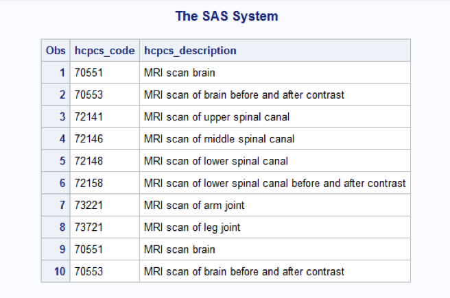

#### c)

Table for c)

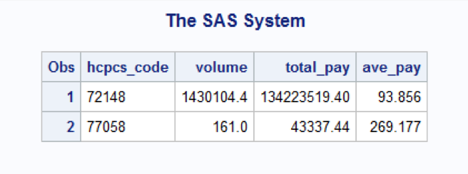

#### d)

Table for d)

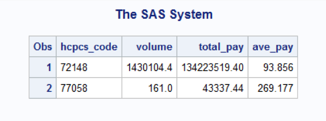

#### e)

```
##      hcpcs_code volume total_pay ave_pay
## [1,]       TRUE   TRUE      TRUE    TRUE
## [2,]       TRUE   TRUE      TRUE    TRUE
```

Thus, results from “c” and “d” match.